# Indian Diabetes Analysis

CSIS3360-001 Group #5

25/03/2021

## ASSOCIATION RULES

### 1. Loading data from .csv file

Uploading a dataset in R workspace and take a look at the first 6 rows:

```r
diabetes_data <- read.csv('diabetes(data).csv')
head(diabetes_data)
```

```
##   Pregnancies Glucose BloodPressure SkinThickness Insulin  BMI
## 1           6     148            72            35       0 33.6
## 2           1      85            66            29       0 26.6
## 3           8     183            64             0       0 23.3
## 4           1      89            66            23      94 28.1
## 5           0     137            40            35     168 43.1
## 6           5     116            74             0       0 25.6
##   DiabetesPedigreeFunction Age Outcome
## 1                    0.627  50       1
## 2                    0.351  31       0
## 3                    0.672  32       1
## 4                    0.167  21       0
## 5                    2.288  33       1
## 6                    0.201  30       0
```

```r
str(diabetes_data) # check the loaded data frame
```

```
## 'data.frame':    771 obs. of  9 variables:
##  $ Pregnancies             : int  6 1 8 1 0 5 3 10 2 8 ...
##  $ Glucose                 : int  148 85 183 89 137 116 78 115 197 125 ...
##  $ BloodPressure           : int  72 66 64 66 40 74 50 0 70 96 ...
##  $ SkinThickness           : int  35 29 0 23 35 0 32 0 45 0 ...
##  $ Insulin                 : int  0 0 0 94 168 0 88 0 543 0 ...
##  $ BMI                     : num  33.6 26.6 23.3 28.1 43.1 25.6 31 35.3 30.5 0 ...
##  $ DiabetesPedigreeFunction: num  0.627 0.351 0.672 0.167 2.288 ...
##  $ Age                     : int  50 31 32 21 33 30 26 29 53 54 ...
##  $ Outcome                 : int  1 0 1 0 1 0 1 0 1 1 ...
```

### 2. Installing & opening required packages

```r
# Installing Packages
#install.packages("arules")
#install.packages("arulesViz")

#Loading package
library(arules)
library(arulesViz)
```

### 3.Train the apriori and fit the model visualize results

```r
# Fitting model
# Training Apriori on the dataset
set.seed = 220 # Setting seed
associa_rules = apriori(data = diabetes_data,
                        parameter = list(support = 0.004,
                                         confidence = 0.2))
```

```
## Apriori
##
## Parameter specification:
##  confidence minval smax arem  aval originalSupport maxtime support minlen
##         0.2    0.1    1 none FALSE            TRUE       5   0.004      1
##  maxlen target  ext
##      10  rules TRUE
##
## Algorithmic control:
##  filter tree heap memopt load sort verbose
##     0.1 TRUE TRUE  FALSE TRUE    2    TRUE
##
## Absolute minimum support count: 3
##
## set item appearances ...[0 item(s)] done [0.00s].
## set transactions ...[24 item(s), 771 transaction(s)] done [0.00s].
## sorting and recoding items ... [24 item(s)] done [0.00s].
## creating transaction tree ... done [0.00s].
## checking subsets of size 1 2 3 4 5 6 7 8 9 done [0.01s].
## writing ... [119239 rule(s)] done [0.02s].
## creating S4 object  ... done [0.04s].
```

### 4. Visualizing the result

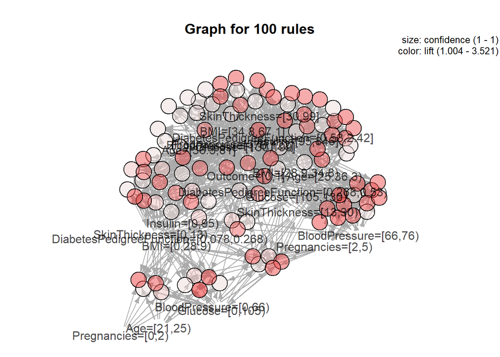

```r
plot(associa_rules, method = "graph",
     measure = "confidence", shading = "lift")
```

## Classification (Naive-Bayes model)

### 1. Installing and adjusting packages

```r
#install.packages("naivebayes")
#install.packages("forecast")
#install.packages("gains")
#install.packages("caret")
#install.packages("e1071")
#install.packages("pROC")

#loading packages for Classification
library("knitr")
library("naivebayes")
library("forecast")
library("gains")
library("caret")
library("e1071")
library("pROC")
```

### 2. Loading data from .csv file

```r
diabetes_data <- read.csv('diabetes(data).csv', stringsAsFactors=T)
str(diabetes_data) # check the loaded data frame
```

```
## 'data.frame':    771 obs. of  9 variables:
##  $ Pregnancies             : int  6 1 8 1 0 5 3 10 2 8 ...
##  $ Glucose                 : int  148 85 183 89 137 116 78 115 197 125 ...
##  $ BloodPressure           : int  72 66 64 66 40 74 50 0 70 96 ...
##  $ SkinThickness           : int  35 29 0 23 35 0 32 0 45 0 ...
##  $ Insulin                 : int  0 0 0 94 168 0 88 0 543 0 ...
##  $ BMI                     : num  33.6 26.6 23.3 28.1 43.1 25.6 31 35.3 30.5 0 ...
##  $ DiabetesPedigreeFunction: num  0.627 0.351 0.672 0.167 2.288 ...
##  $ Age                     : int  50 31 32 21 33 30 26 29 53 54 ...
##  $ Outcome                 : int  1 0 1 0 1 0 1 0 1 1 ...
```

### 3. Data pre-processing works.

Factorizing each Column (because it is simple numerical data, not a factor).

```r
## Factorizing "Pregnancies" Column.
diabetes_data <- within(diabetes_data, {
  stat_Preg = character(0)
  stat_Preg[ Pregnancies == 0 ] = "0"
  stat_Preg[ Pregnancies >= 1 & Pregnancies < 4 ] = "Between 1 and 3"
  stat_Preg[ Pregnancies >= 4 & Pregnancies < 7 ] = "Between 4 and 6"
  stat_Preg[ Pregnancies >= 7 & Pregnancies < 10 ] = "Between 7 and 9"
  stat_Preg[ Pregnancies >= 10 ] = "Greater than or equal to 10"
  stat_Preg = factor(stat_Preg, level = c("0", "Between 1 and 3", "Between 4 and 6", "Between 7 and 9", "Greater than or equal to 10"))
})

## Factorizing "Glucose" Column.
diabetes_data <- within(diabetes_data, {
  stat_Glu = character(0)
  stat_Glu[ Glucose < 41 ] = "Less than 41"
  stat_Glu[ Glucose >= 41 & Glucose < 81 ] = "Between 41 and 80"
  stat_Glu[ Glucose >= 81 & Glucose < 121 ] = "Between 81 and 120"
  stat_Glu[ Glucose >= 121 & Glucose < 161 ] = "Between 121 and 160"
  stat_Glu[ Glucose >= 161 & Glucose < 201  ] = "Between 161 and 200"
  stat_Glu = factor(stat_Glu, level = c("Less than 41", "Between 41 and 80", "Between 81 and 120", "Between 121 and 160", "Between 161 and 200"))
})

## Factorizing "BloodPressure" Column.
diabetes_data <- within(diabetes_data, {
  stat_Blood = character(0)
  stat_Blood[ BloodPressure < 26 ] = "Less than 26"
  stat_Blood[ BloodPressure >= 26 & BloodPressure < 51 ] = "Between 26 and 50"
  stat_Blood[ BloodPressure >= 51 & BloodPressure < 76 ] = "Between 51 and 75"
  stat_Blood[ BloodPressure >= 76 & BloodPressure < 101 ] = "Between 76 and 100"
  stat_Blood[ BloodPressure >= 101 & BloodPressure < 126  ] = "Between 101 and 125"
  stat_Blood = factor(stat_Blood, level = c("Less than 26", "Between 26 and 50", "Between 51 and 75", "Between 76 and 100", "Between 101 and 125"))
})

## Factorizing "SkinThickness" Column.
diabetes_data <- within(diabetes_data, {
  stat_Skin = character(0)
  stat_Skin[ SkinThickness < 21 ] = "Less than 21"
  stat_Skin[ SkinThickness >= 21 & SkinThickness < 41 ] = "Between 21 and 40"
  stat_Skin[ SkinThickness >= 41 & SkinThickness < 61 ] = "Between 41 and 60"
  stat_Skin[ SkinThickness >= 61 & SkinThickness < 81 ] = "Between 61 and 80"
  stat_Skin[ SkinThickness >= 81 & SkinThickness < 101  ] = "Between 81 and 100"
  stat_Skin = factor(stat_Skin, level = c("Less than 21", "Between 21 and 40", "Between 41 and 60", "Between 61 and 80", "Between 81 and 100"))
})

## Factorizing "Insulin" Column.
diabetes_data <- within(diabetes_data, {
  stat_Ins = character(0)
  stat_Ins[ Insulin < 201 ] = "Less than 201"
  stat_Ins[ Insulin >= 201 & Insulin < 401 ] = "Between 201 and 400"
  stat_Ins[ Insulin >= 401 & Insulin < 601 ] = "Between 401 and 600"
  stat_Ins[ Insulin >= 601 & Insulin < 801 ] = "Between 601 and 800"
  stat_Ins[ Insulin >= 801 & Insulin < 1001 ] = "Between 801 and 1000"
  stat_Ins = factor(stat_Ins, level = c("Less than 201", "Between 201 and 400", "Between 401 and 600", "Between 601 and 800", "Between 801 and 1000"))
})

## Factorizing "BMI" Column.
diabetes_data <- within(diabetes_data, {
  stat_BMI = character(0)
  stat_BMI[ BMI < 16 ] = "Less than 16"
  stat_BMI[ BMI >= 16 & BMI < 31 ] = "Between 16 and 30"
  stat_BMI[ BMI >= 31 & BMI < 46 ] = "Between 31 and 45"
  stat_BMI[ BMI >= 46 & BMI < 61 ] = "Between 46 and 60"
  stat_BMI[ BMI >= 61 & BMI < 81  ] = "Between 61 and 80"
  stat_BMI = factor(stat_BMI, level = c("Less than 16", "Between 16 and 30", "Between 31 and 45", "Between 46 and 60", "Between 61 and 80"))
})

## Factorizing "DiabetesPedigreeFunction" Column.
diabetes_data <- within(diabetes_data, {
  stat_PedFunc = character(0)
  stat_PedFunc[ DiabetesPedigreeFunction < 0.6 ] = "Less than 0.6"
  stat_PedFunc[ DiabetesPedigreeFunction >= 0.6 & DiabetesPedigreeFunction < 1.1 ] = "Between 0.6 and 1.0"
  stat_PedFunc[ DiabetesPedigreeFunction >= 1.1 & DiabetesPedigreeFunction < 1.6 ] = "Between 1.1 and 1.5"
  stat_PedFunc[ DiabetesPedigreeFunction >= 1.6 & DiabetesPedigreeFunction < 2.1] = "Between 1.6 and 2.0"
  stat_PedFunc[ DiabetesPedigreeFunction >= 2.1 & DiabetesPedigreeFunction < 2.6  ] = "Between 2.1 and 2.5"
  stat_PedFunc = factor(stat_PedFunc, level = c("Less than 0.6", "Between 0.6 and 1.0", "Between 1.1 and 1.5", "Between 1.6 and 2.0", "Between 2.1 and 2.5"))
})

## Factorizing "Age" Column.
diabetes_data <- within(diabetes_data, {
  stat_Age = character(0)
  stat_Age[ Age < 21 ] = "Less than 21"
  stat_Age[ Age >= 21 & Age < 41 ] = "Between 21 and 40"
  stat_Age[ Age >= 41 & Age < 61 ] = "Between 41 and 60"
  stat_Age[ Age >= 61 & Age < 81 ] = "Between 61 and 80"
  stat_Age[ Age >= 81 & Age < 101  ] = "Between 81 and 100"
  stat_Age = factor(stat_Age, level = c("Less than 21", "Between 21 and 40", "Between 41 and 60", "Between 61 and 80", "Between 81 and 100"))
})

diabetes_data[1:10, c(10:12)]
```

```
##                      stat_Preg            stat_Glu         stat_Blood
## 1              Between 4 and 6 Between 121 and 160  Between 51 and 75
## 2              Between 1 and 3  Between 81 and 120  Between 51 and 75
## 3              Between 7 and 9 Between 161 and 200  Between 51 and 75
## 4              Between 1 and 3  Between 81 and 120  Between 51 and 75
## 5                            0 Between 121 and 160  Between 26 and 50
## 6              Between 4 and 6  Between 81 and 120  Between 51 and 75
## 7              Between 1 and 3   Between 41 and 80  Between 26 and 50
## 8  Greater than or equal to 10  Between 81 and 120       Less than 26
## 9              Between 1 and 3 Between 161 and 200  Between 51 and 75
## 10             Between 7 and 9 Between 121 and 160 Between 76 and 100
```

```r
diabetes_data[1:10, c(13:15)]
```

```
##            stat_Skin            stat_Ins          stat_BMI
## 1  Between 21 and 40       Less than 201 Between 31 and 45
## 2  Between 21 and 40       Less than 201 Between 16 and 30
## 3       Less than 21       Less than 201 Between 16 and 30
## 4  Between 21 and 40       Less than 201 Between 16 and 30
## 5  Between 21 and 40       Less than 201 Between 31 and 45
## 6       Less than 21       Less than 201 Between 16 and 30
## 7  Between 21 and 40       Less than 201 Between 31 and 45
## 8       Less than 21       Less than 201 Between 31 and 45
## 9  Between 41 and 60 Between 401 and 600 Between 16 and 30
## 10      Less than 21       Less than 201      Less than 16
```

```r
diabetes_data[1:10, c(16:17, 9)]
```

```
##           stat_PedFunc          stat_Age Outcome
## 1  Between 0.6 and 1.0 Between 41 and 60       1
## 2        Less than 0.6 Between 21 and 40       0
## 3  Between 0.6 and 1.0 Between 21 and 40       1
## 4        Less than 0.6 Between 21 and 40       0
## 5  Between 2.1 and 2.5 Between 21 and 40       1
## 6        Less than 0.6 Between 21 and 40       0
## 7        Less than 0.6 Between 21 and 40       1
## 8        Less than 0.6 Between 21 and 40       0
## 9        Less than 0.6 Between 41 and 60       1
## 10       Less than 0.6 Between 41 and 60       1
```

Set the Factors for Outcome column

```r
diabetes_data$Outcome <- factor(diabetes_data$Outcome, levels=c("0","1"))
```

### 4. Presenting distribution table with X - Y factors

1. Distribution table (Pregnancies - Satisfaction)

```r
xtabs(~stat_Preg+Outcome, data = diabetes_data)
```

```
##                              Outcome
## stat_Preg                       0   1
##   0                            73  38
##   Between 1 and 3             238  75
##   Between 4 and 6             115  60
##   Between 7 and 9              46  65
##   Greater than or equal to 10  28  30
```

2. Distribution table (Glucose - Satisfaction)

```r
xtabs(~stat_Glu+Outcome, data = diabetes_data)
```

```
##                      Outcome
## stat_Glu                0   1
##   Less than 41          3   2
##   Between 41 and 80    40   2
##   Between 81 and 120  303  69
##   Between 121 and 160 136 112
##   Between 161 and 200  18  83
```

3. Distribution table (BloodPressure - Satisfaction)

```r
xtabs(~stat_Blood+Outcome, data = diabetes_data)
```

```
##                      Outcome
## stat_Blood              0   1
##   Less than 26         20  16
##   Between 26 and 50    20   8
##   Between 51 and 75   296 119
##   Between 76 and 100  159 117
##   Between 101 and 125   5   8
```

4. Distribution table (SkinThickness - Satisfaction)

```r
xtabs(~stat_Skin+Outcome, data = diabetes_data)
```

```
##                     Outcome
## stat_Skin              0   1
##   Less than 21       246 105
##   Between 21 and 40  217 126
##   Between 41 and 60   37  35
##   Between 61 and 80    0   1
##   Between 81 and 100   0   1
```

5. Distribution table (Insulin - Satisfaction)

```r
xtabs(~stat_Ins+Outcome, data = diabetes_data)
```

```
##                       Outcome
## stat_Ins                 0   1
##   Less than 201        461 222
##   Between 201 and 400   31  34
##   Between 401 and 600    6  11
##   Between 601 and 800    2   0
##   Between 801 and 1000   0   1
```

6. Distribution table (BMI - Satisfaction)

```r
xtabs(~stat_BMI+Outcome, data = diabetes_data)
```

```
##                    Outcome
## stat_BMI              0   1
##   Less than 16        9   2
##   Between 16 and 30 264  68
##   Between 31 and 45 218 182
##   Between 46 and 60   9  15
##   Between 61 and 80   0   1
```

7. Distribution table (DiabetesPedigreeFunction - Satisfaction)

```r
xtabs(~stat_PedFunc+Outcome, data = diabetes_data)
```

```
##                      Outcome
## stat_PedFunc            0   1
##   Less than 0.6       390 172
##   Between 0.6 and 1.0  93  71
##   Between 1.1 and 1.5  11  21
##   Between 1.6 and 2.0   5   1
##   Between 2.1 and 2.5   1   3
```

8. Distribution table (Age - Satisfaction)

```r
xtabs(~stat_Age+Outcome, data = diabetes_data)
```

```
##                     Outcome
## stat_Age               0   1
##   Less than 21         0   0
##   Between 21 and 40  408 166
##   Between 41 and 60   72  95
##   Between 61 and 80   19   7
##   Between 81 and 100   1   0
```

### 5. Creating training and validating data for Naive-Bayes modeling

Setting ‘select’ variable to fix columns which will be used for testing (Xs).

- 10th column = Pregnancies
- 11th column = Glucose
- 12th column = BloodPressure
- 13th column = SkinThickness
- 14th column = Insulin
- 15th column = BMI
- 16th column = DiabetesPedigreeFunction
- 17th column = Age
- 9th column = Outcome

```r
selected.var <- c(10:17, 9)
```

making index variable for splitting up training and validating data frame.

- size of index = 768 (without 3 rows for testing)
- range of index = from 1 to 768 (without 3 rows for testing)

```r
train.index <- sample(c(1:768), 768)
```

making data frame for training by using train.index and selected.var(columns)

```r
train.df <- diabetes_data[train.index, selected.var]
```

making data frame for validating by using -train.index and selected.var(columns)

```r
valid.df <- diabetes_data[-train.index, selected.var]
```

checking the structures of each data frame

```r
str(train.df)
```

```
## 'data.frame':    768 obs. of  9 variables:
##  $ stat_Preg   : Factor w/ 5 levels "0","Between 1 and 3",..: 3 2 2 1 2 4 2 1 2 2 ...
##  $ stat_Glu    : Factor w/ 5 levels "Less than 41",..: 5 3 4 4 4 5 3 3 3 4 ...
##  $ stat_Blood  : Factor w/ 5 levels "Less than 26",..: 3 3 3 4 2 4 3 3 3 3 ...
##  $ stat_Skin   : Factor w/ 5 levels "Less than 21",..: 2 2 2 1 3 1 1 3 1 2 ...
##  $ stat_Ins    : Factor w/ 5 levels "Less than 201",..: 4 1 2 1 1 1 1 1 1 1 ...
##  $ stat_BMI    : Factor w/ 5 levels "Less than 16",..: 3 3 3 3 3 2 2 3 2 3 ...
##  $ stat_PedFunc: Factor w/ 5 levels "Less than 0.6",..: 5 2 2 2 2 1 1 1 1 1 ...
##  $ stat_Age    : Factor w/ 5 levels "Less than 21",..: 2 2 2 2 2 3 2 2 2 2 ...
##  $ Outcome     : Factor w/ 2 levels "0","1": 1 1 2 2 2 2 1 1 1 2 ...
```

```r
str(valid.df)
```

```
## 'data.frame':    3 obs. of  9 variables:
##  $ stat_Preg   : Factor w/ 5 levels "0","Between 1 and 3",..: 2 3 3
##  $ stat_Glu    : Factor w/ 5 levels "Less than 41",..: 4 2 4
##  $ stat_Blood  : Factor w/ 5 levels "Less than 26",..: 4 3 4
##  $ stat_Skin   : Factor w/ 5 levels "Less than 21",..: 2 2 2
##  $ stat_Ins    : Factor w/ 5 levels "Less than 201",..: 1 1 1
##  $ stat_BMI    : Factor w/ 5 levels "Less than 16",..: 2 3 3
##  $ stat_PedFunc: Factor w/ 5 levels "Less than 0.6",..: 1 2 1
##  $ stat_Age    : Factor w/ 5 levels "Less than 21",..: 3 2 3
##  $ Outcome     : Factor w/ 2 levels "0","1": NA NA NA
```

### 6.Running Naive-Bayes classification

Initializing result variable with naiveBayes function by using train data frame

```r
results.nb <- naive_bayes(Outcome ~., data = train.df, laplace = 1)
results.nb
```

```
##
## ================================== Naive Bayes ==================================
##
##  Call:
## naive_bayes.formula(formula = Outcome ~ ., data = train.df, laplace = 1)
##
## ---------------------------------------------------------------------------------
##
## Laplace smoothing: 1
##
## ---------------------------------------------------------------------------------
##
##  A priori probabilities:
##
##         0         1
## 0.6510417 0.3489583
##
## ---------------------------------------------------------------------------------
##
##  Tables:
##
## ---------------------------------------------------------------------------------
##  ::: stat_Preg (Categorical)
## ---------------------------------------------------------------------------------
##
## stat_Preg                              0          1
##   0                           0.14653465 0.14285714
##   Between 1 and 3             0.47326733 0.27838828
##   Between 4 and 6             0.22970297 0.22344322
##   Between 7 and 9             0.09306931 0.24175824
##   Greater than or equal to 10 0.05742574 0.11355311
##
## ---------------------------------------------------------------------------------
##  ::: stat_Glu (Categorical)
## ---------------------------------------------------------------------------------
##
## stat_Glu                        0           1
##   Less than 41        0.007920792 0.010989011
##   Between 41 and 80   0.081188119 0.010989011
##   Between 81 and 120  0.601980198 0.256410256
```

[output cut: 26 more lines]

```
##  ::: stat_Ins (Categorical)
## ---------------------------------------------------------------------------------
##
## stat_Ins                         0           1
##   Less than 201        0.914851485 0.816849817
##   Between 201 and 400  0.063366337 0.128205128
##   Between 401 and 600  0.013861386 0.043956044
##   Between 601 and 800  0.005940594 0.003663004
##   Between 801 and 1000 0.001980198 0.007326007
##
## ---------------------------------------------------------------------------------
##
## # ... and 3 more tables
##
## ---------------------------------------------------------------------------------
```

### 7. Creating probability tables to compare values of each factor

```r
results_Preg.t <- table(train.df$stat_Preg, train.df$Outcome)
results_Glu.t <- table(train.df$stat_Glu, train.df$Outcome)
results_Blood.t <- table(train.df$stat_Blood, train.df$Outcome)
results_Skin.t <- table(train.df$stat_Skin, train.df$Outcome)
results_Ins.t <- table(train.df$stat_Ins, train.df$Outcome)
results_BMI.t <- table(train.df$stat_BMI, train.df$Outcome)
results_Ped.t <- table(train.df$stat_PedFunc, train.df$Outcome)
results_Age.t <- table(train.df$stat_Age, train.df$Outcome)

# margin=2 means that considering 'column' as 100%.
results.p1 <- prop.table(results_Preg.t, margin = 2)
results.p2 <- prop.table(results_Glu.t, margin = 2)
results.p3 <- prop.table(results_Blood.t, margin = 2)
results.p4 <- prop.table(results_Skin.t, margin = 2)
results.p5 <- prop.table(results_Ins.t, margin = 2)
results.p6 <- prop.table(results_BMI.t, margin = 2)
results.p7 <- prop.table(results_Ped.t, margin = 2)
results.p8 <- prop.table(results_Age.t, margin = 2)
```

1. Probability table (Pregnancies - Satisfaction)

```r
results.p1
```

```
##
##                                       0         1
##   0                           0.1460000 0.1417910
##   Between 1 and 3             0.4760000 0.2798507
##   Between 4 and 6             0.2300000 0.2238806
##   Between 7 and 9             0.0920000 0.2425373
##   Greater than or equal to 10 0.0560000 0.1119403
```

2. Probability table (Glucose - Satisfaction)

```r
results.p2
```

```
##
##                                 0           1
##   Less than 41        0.006000000 0.007462687
##   Between 41 and 80   0.080000000 0.007462687
##   Between 81 and 120  0.606000000 0.257462687
##   Between 121 and 160 0.272000000 0.417910448
##   Between 161 and 200 0.036000000 0.309701493
```

3. Probability table (BloodPressure - Satisfaction)

```r
results.p3
```

```
##
##                                0          1
##   Less than 26        0.04000000 0.05970149
##   Between 26 and 50   0.04000000 0.02985075
##   Between 51 and 75   0.59200000 0.44402985
##   Between 76 and 100  0.31800000 0.43656716
##   Between 101 and 125 0.01000000 0.02985075
```

4. Probability table (SkinThickness - Satisfaction)

```r
results.p4
```

```
##
##                                0           1
##   Less than 21       0.492000000 0.391791045
##   Between 21 and 40  0.434000000 0.470149254
##   Between 41 and 60  0.074000000 0.130597015
##   Between 61 and 80  0.000000000 0.003731343
##   Between 81 and 100 0.000000000 0.003731343
```

5. Probability table (Insulin - Satisfaction)

```r
results.p5
```

```
##
##                                  0           1
##   Less than 201        0.922000000 0.828358209
##   Between 201 and 400  0.062000000 0.126865672
##   Between 401 and 600  0.012000000 0.041044776
##   Between 601 and 800  0.004000000 0.000000000
##   Between 801 and 1000 0.000000000 0.003731343
```

6. Probability table (BMI - Satisfaction)

```r
results.p6
```

```
##
##                               0           1
##   Less than 16      0.018000000 0.007462687
##   Between 16 and 30 0.528000000 0.253731343
##   Between 31 and 45 0.436000000 0.679104478
##   Between 46 and 60 0.018000000 0.055970149
##   Between 61 and 80 0.000000000 0.003731343
```

7. Probability table (DiabetesPedigreeFunction - Satisfaction)

```r
results.p7
```

```
##
##                                 0           1
##   Less than 0.6       0.780000000 0.641791045
##   Between 0.6 and 1.0 0.186000000 0.264925373
##   Between 1.1 and 1.5 0.022000000 0.078358209
##   Between 1.6 and 2.0 0.010000000 0.003731343
##   Between 2.1 and 2.5 0.002000000 0.011194030
```

8. Probability table (Age - Satisfaction)

```r
results.p8
```

```
##
##                              0         1
##   Less than 21       0.0000000 0.0000000
##   Between 21 and 40  0.8160000 0.6194030
##   Between 41 and 60  0.1440000 0.3544776
##   Between 61 and 80  0.0380000 0.0261194
##   Between 81 and 100 0.0020000 0.0000000
```

### 8. Predicting probabilities with validating data

- Q1. Assuming results as a probability of a 46-year-old patient with only one pregnancy with 121 glucose concentration, 88 blood pressure, 32 skin thickness, 82 insulin, 24.2 BMI and 0.286 diabetesPedigreeFunction,
- Q2. Assuming results as a probability of a 37-year-old patient with 4 pregnancies with 57 glucose concentration, 61 blood pressure, 24 skin thickness, 190 insulin, 35.5 BMI and 0.871 diabetesPedigreeFunction,
- Q3. Assuming results as a probability of a 52-year-old patient with 5 pregnancies with 154 glucose concentration, 89 blood pressure, 33 skin thickness, 164 insulin, 42.7 BMI and 0.423 diabetesPedigreeFunction,

```r
# newdata = new data for prediction
# type = raw(or, prob = probability prediction) , class (belonging class)

pred.prob <- predict(results.nb, newdata = valid.df, type = "prob")
pred.class <- predict(results.nb, newdata = valid.df, type = "class")

# actual = actual data
# predicted = predicted data

df <- data.frame(actual = valid.df$Outcome,
                 predicted = pred.class,
                 pred.prob)

df # check the result
```

```
##   actual predicted        X0         X1
## 1   <NA>         0 0.6228334 0.37716657
## 2   <NA>         0 0.9225480 0.07745199
## 3   <NA>         1 0.2373145 0.76268549
```

#### ANSWER : This result makes it possible to predict that the first two patients will not have diabates, and the last patient will have diabetes. [0, 0, 1]

### 9. Confusion Matrix

The misclassification is 0.2395833

```r
 ## Confusion Matrix - train data
p1 <- predict(results.nb, train.df)
tab1 <- table(p1, train.df$Outcome)

tab1 # check misclassification table
```

```
##
## p1    0   1
##   0 424 108
##   1  76 160
```

```r
# misclassification
1 - sum(diag(tab1)) / sum(tab1)
```

```
## [1] 0.2395833
```

The misclassification is NaN ()

```r
## Confusion Matrix - test data
p2 <- predict(results.nb, valid.df)
tab2 <- table(p2, valid.df$Outcome)

tab2 # check misclassification table
```

```
##
## p2  0 1
##   0 0 0
##   1 0 0
```

```r
# misclassification
1 - sum(diag(tab2)) / sum(tab2)
```

```
## [1] NaN
```

## Plots

### 1. Density Plots for each distribution table

Result plot of each distribution table

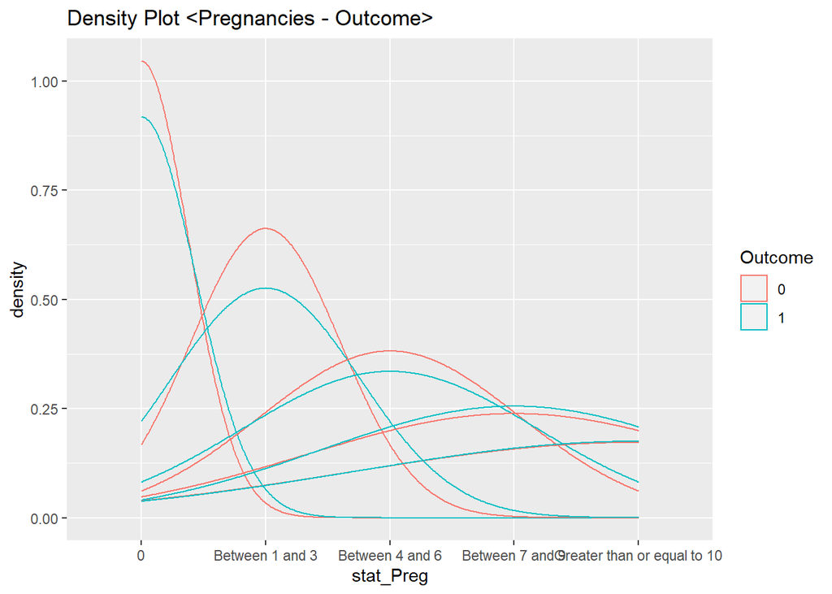

```r
ggplot(data=train.df) +
  geom_density(mapping=aes(x=stat_Preg, colour = Outcome)) +
  ggtitle("Density Plot <Pregnancies - Outcome>")
```

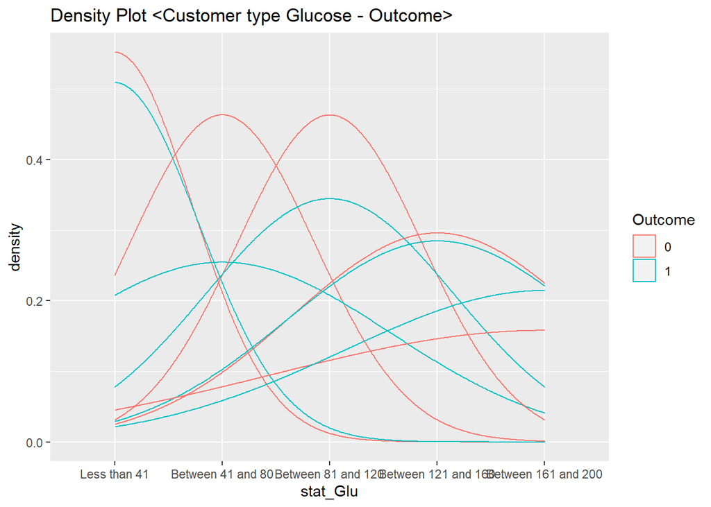

```r
ggplot(data=train.df) +
  geom_density(mapping=aes(x=stat_Glu, colour = Outcome)) +
  ggtitle("Density Plot <Customer type Glucose - Outcome>")
```

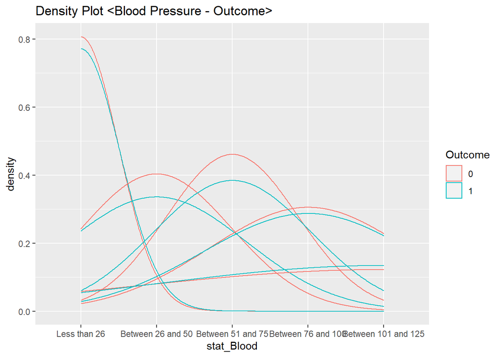

```r
ggplot(data=train.df) +
  geom_density(mapping=aes(x=stat_Blood, colour = Outcome)) +
  ggtitle("Density Plot <Blood Pressure - Outcome>")
```

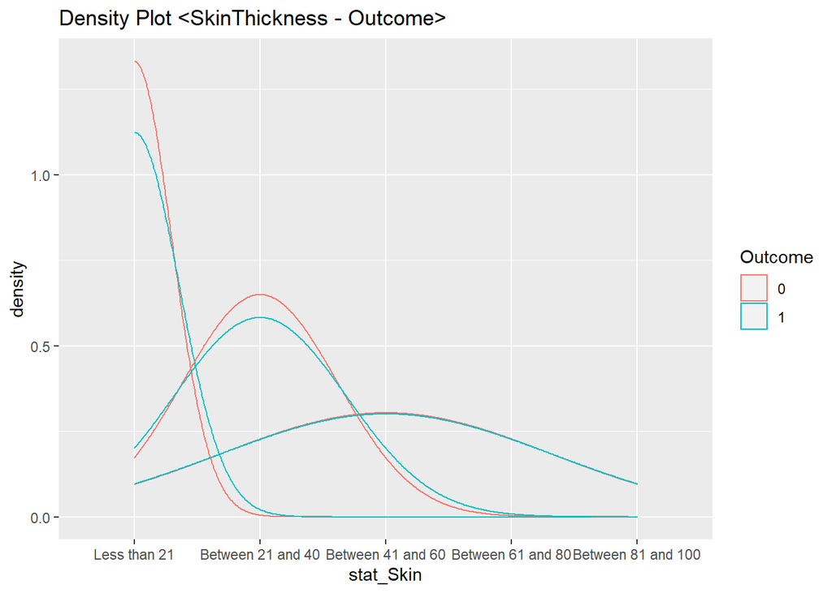

```r
ggplot(data=train.df) +
  geom_density(mapping=aes(x=stat_Skin, colour = Outcome)) +
  ggtitle("Density Plot <SkinThickness - Outcome>")
```

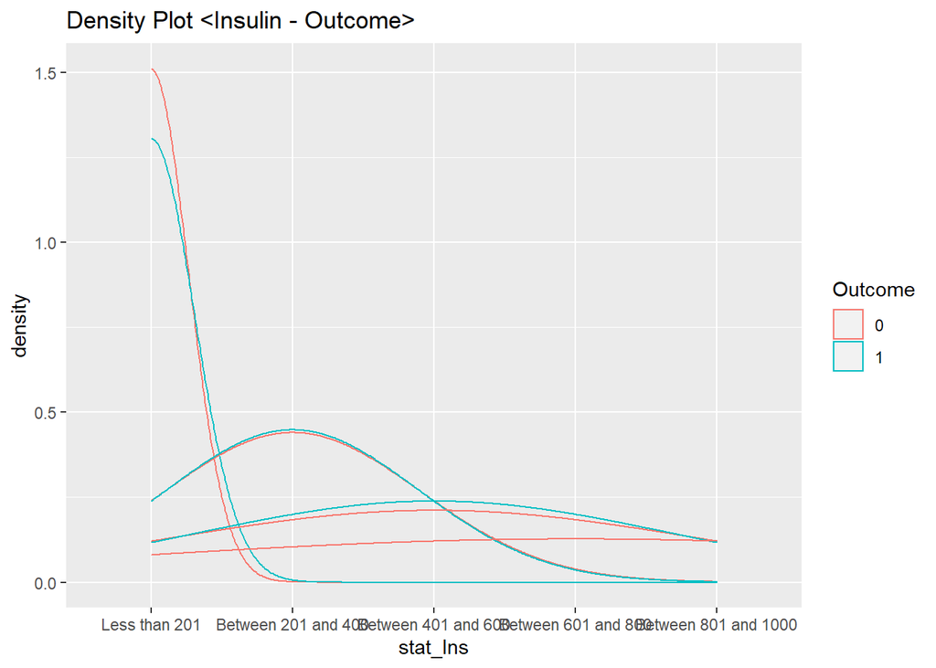

```r
ggplot(data=train.df) +
  geom_density(mapping=aes(x=stat_Ins, colour = Outcome)) +
  ggtitle("Density Plot <Insulin - Outcome>")
```

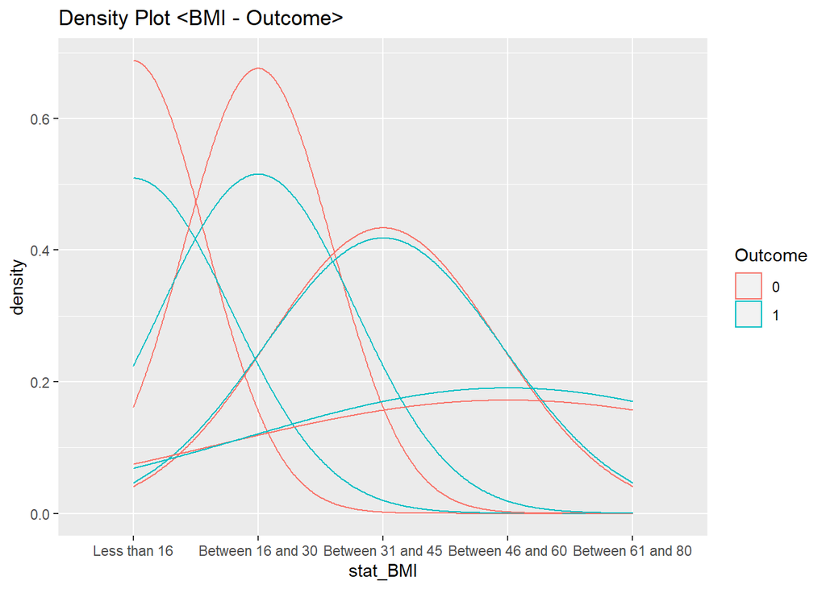

```r
ggplot(data=train.df) +
  geom_density(mapping=aes(x=stat_BMI, colour = Outcome)) +
  ggtitle("Density Plot <BMI - Outcome>")
```

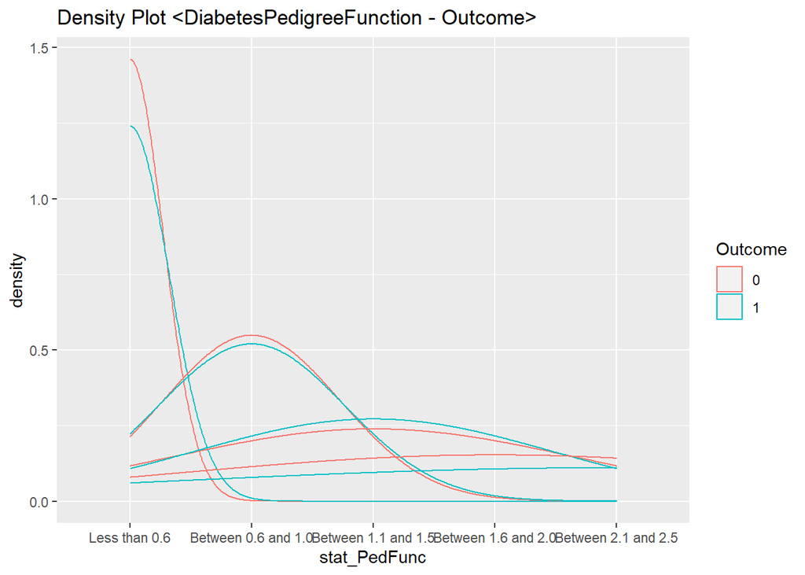

```r
ggplot(data=train.df) +
  geom_density(mapping=aes(x=stat_PedFunc, colour = Outcome)) +
  ggtitle("Density Plot <DiabetesPedigreeFunction - Outcome>")
```

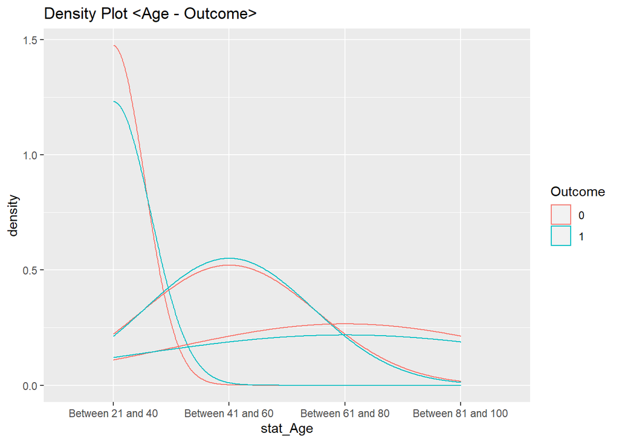

```r
ggplot(data=train.df) +
  geom_density(mapping=aes(x=stat_Age, colour = Outcome)) +
  ggtitle("Density Plot <Age - Outcome>")
```

### 2. Result plot for Naive-Bayes classification

Result plot of Naive-Bayes classification

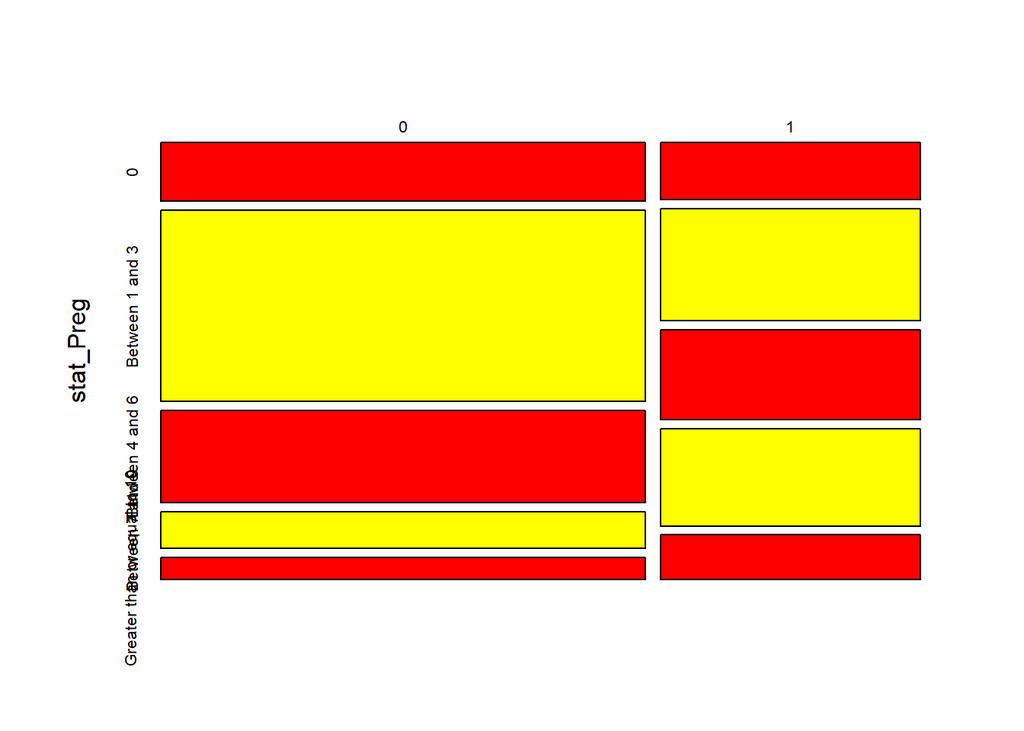

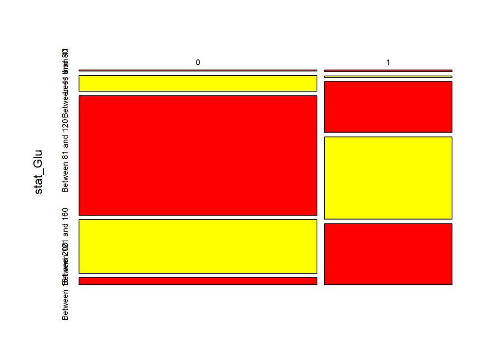

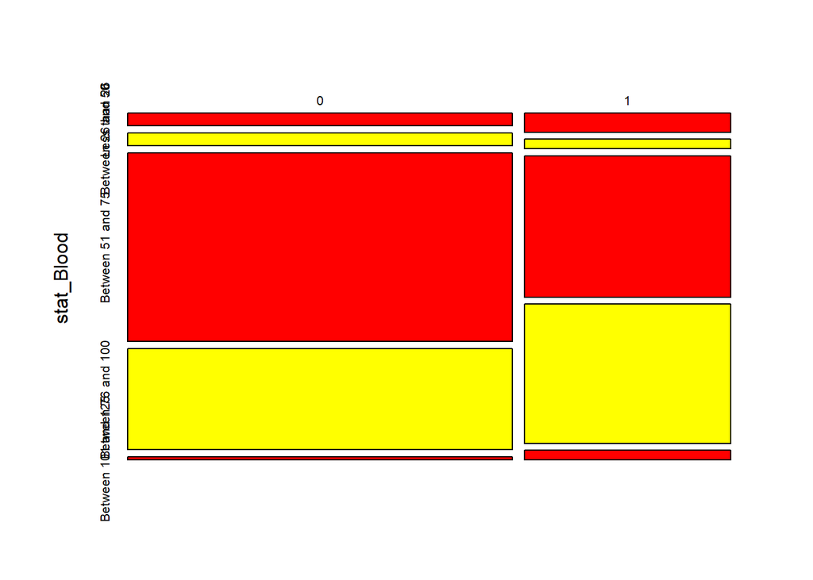

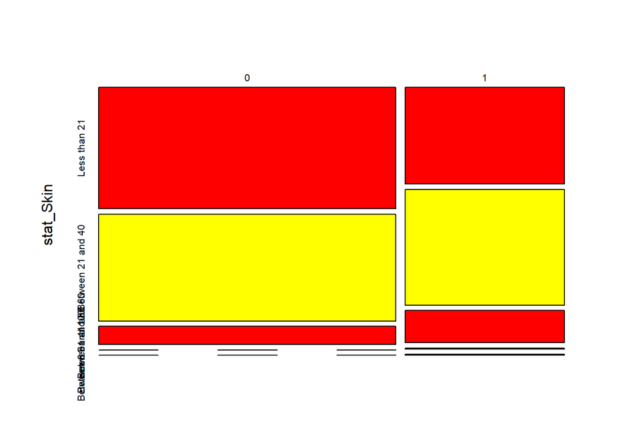

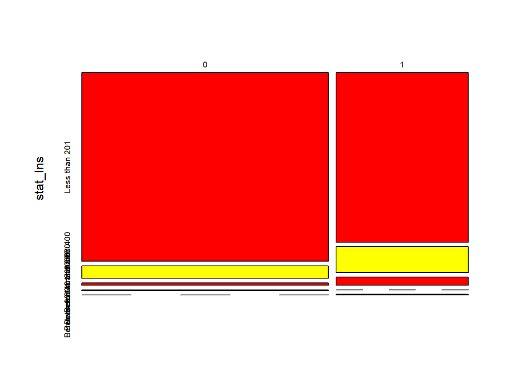

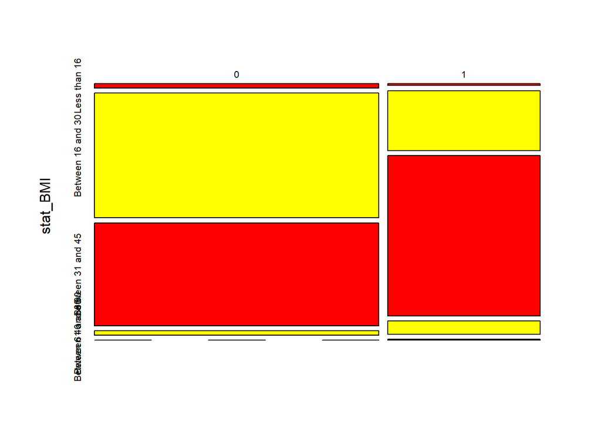

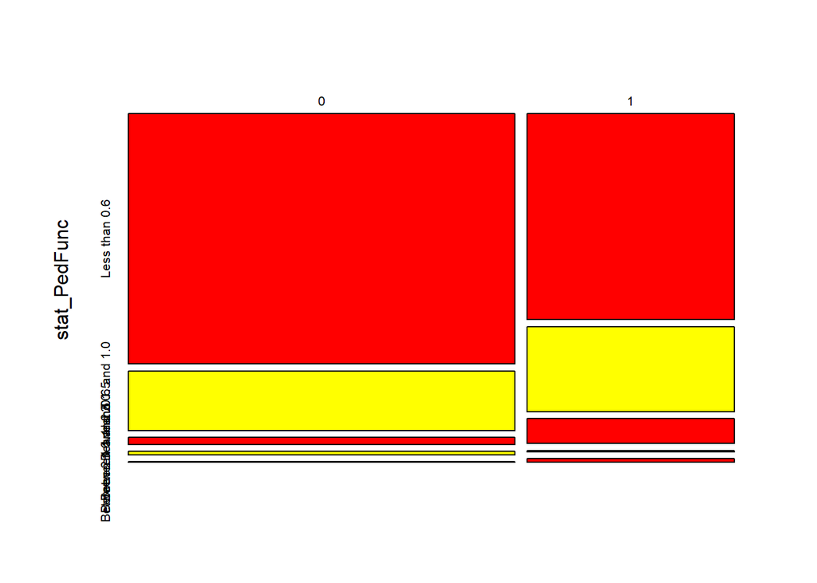

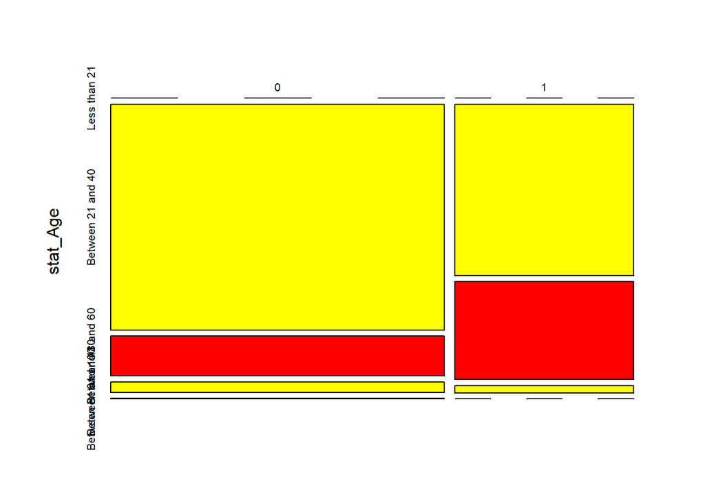

```r
results.nb <- naive_bayes(Outcome ~., data = train.df) # for making simple plots
plot(results.nb)
```

## CLUSTERING

### 1. Loading packages

```r
#install.packages("factoextra")
#install.packages("cluster")
#install.packages("magrittr")

library("cluster")
library("factoextra")
library("magrittr")
```

### 2. Data Preparation

Handling Null values (missing data).

```r
#Read csv file
diabetes_data <- read.csv("diabetes(data).csv", header=TRUE)

sapply(diabetes_data, function(x) sum(is.na(x)))
```

```
##              Pregnancies                  Glucose            BloodPressure
##                        0                        0                        0
##            SkinThickness                  Insulin                      BMI
##                        0                        0                        0
## DiabetesPedigreeFunction                      Age                  Outcome
##                        0                        0                        3
```

[output not shown]

### 3.Determine kmeans and compute the cluster

Evaluate the optimal number of cluster

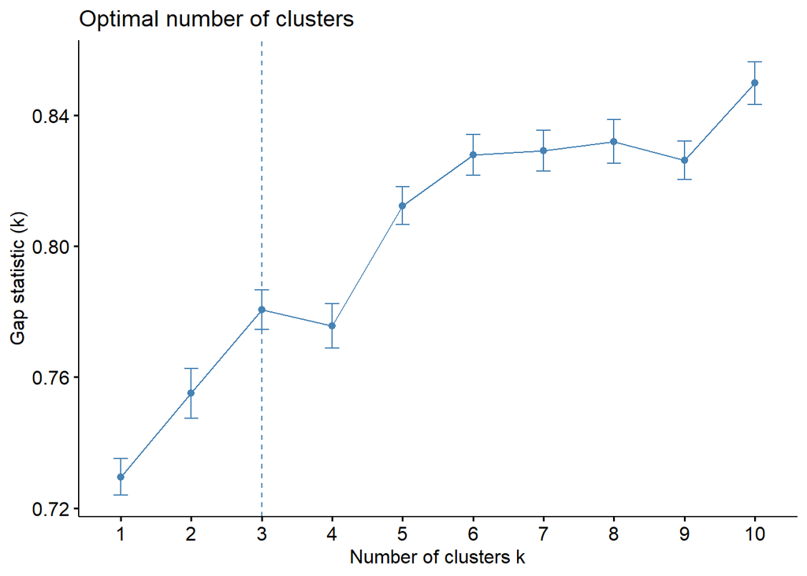

```r
fviz_nbclust(diabetes_data, kmeans, method = "gap_stat")
```

From this result, k will set as 3, nstart will be 100, in which:

Seeds are used to create a starting point for numbers that are created randomly. nstart option that attempts multiple initial configurations and reports on the best one within the kmeans function.

```r
set.seed(120)
km.res <- kmeans(diabetes_data, 3, nstart = 100)
```

### 4. Visualize Partitioning Clustering

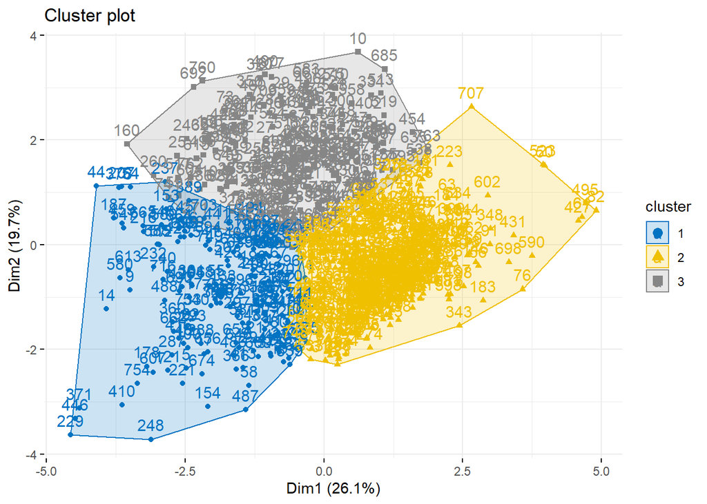

```r
fviz_cluster(km.res, data = diabetes_data,
             ellipse.type = "convex",
             palette = "jco",
             ggtheme = theme_minimal())
```